# **secr** simulations

## Results

```
##    CVlambda0 lambda nvalid       RBD    seRBD lambda.1 selambda
## 1        0.0    0.9    200  0.008443 0.008824   0.9025 0.002690
## 2        0.2    0.9    200 -0.023766 0.009180   0.9007 0.002830
## 3        0.4    0.9    200 -0.103230 0.007558   0.9025 0.002748
## 4        0.6    0.9    200 -0.184534 0.007413   0.9011 0.002605
## 5        0.8    0.9    200 -0.270015 0.005981   0.8957 0.002925
## 6        0.0    1.1    200  0.008313 0.008301   1.1001 0.002745
## 7        0.2    1.1    200 -0.029472 0.008215   1.1004 0.003024
## 8        0.4    1.1    200 -0.094439 0.007828   1.0975 0.002888
## 9        0.6    1.1    200 -0.181581 0.006774   1.0996 0.002582
## 10       0.8    1.1    200 -0.267342 0.006509   1.0995 0.002876
```

```
##    CVlambda0 truelambda lambda selambda
## 1        0.0        0.9 0.9055  0.02842
## 2        0.2        0.9 0.9092  0.01670
## 3        0.4        0.9 0.9142  0.01212
## 4        0.6        0.9 0.9133  0.01361
## 5        0.8        0.9 0.9335  0.01283
## 6        0.0        1.1 1.0963  0.01727
## 7        0.2        1.1 1.0953  0.01697
## 8        0.4        1.1 1.0886  0.01766
## 9        0.6        1.1 1.0963  0.01267
## 10       0.8        1.1 1.0972  0.02270
```

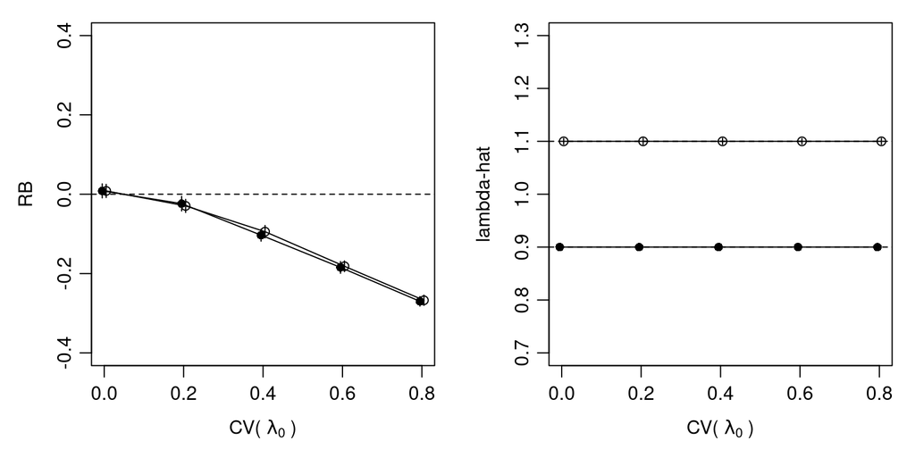

Relative bias of parameter estimates from null model given individual variation

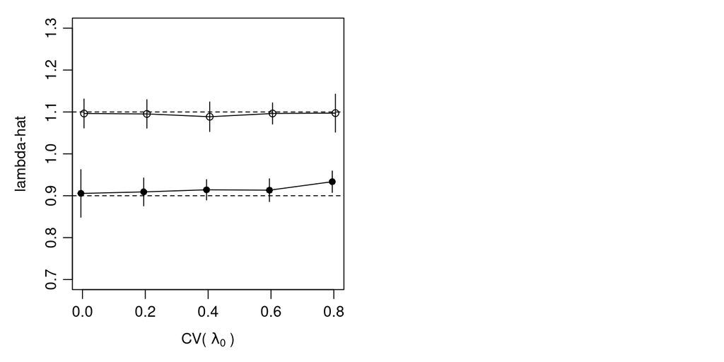

## Interpretation

Estimates of density from the null model are moderately sensitive to individual variation in $\lambda_0$, but estimates of population trend $\lambda$ are unbiased.

## References

Hines, J. E. and Nichols, J. D. 2002. Investigations of potential bias in the estimation of $\lambda$ using Pradel’s (1996) model for capture–recapture data. Journal of Applied Statistics 29: 573–587.

Nichols, J. D. and Hines, J. E. 2002. Approaches for the direct estimation of $\lambda$, and demographic contributions to $\lambda$, using capture–recapture data, Journal of Applied Statistics 29: 539–568.